# Optimal Treatment Analysis

## Outcome Variable

**Outcome Variable:** haz

## Predictor Variables

**Intervention Variable:** impsan

**Adjustment Set:**

- arm
- sex
- W_mage
- meducyrs
- feducyrs
- hhwealth_quart
- hfoodsec
- W_mhtcm
- W_mwtkg
- W_mbmi
- W_nrooms
- W_nchldlt5
- W_parity
- impfloor
- safeh20
- delta_W_mage
- delta_meducyrs
- delta_feducyrs
- delta_hhwealth_quart
- delta_hfoodsec
- delta_W_mhtcm
- delta_W_mwtkg
- delta_W_mbmi
- delta_W_nrooms
- delta_W_nchldlt5
- delta_W_parity
- delta_impfloor
- delta_safeh20

## Stratifying Variables

The analysis was stratified on these variable(s):

- agecat
- studyid
- country

## Data Summary

| agecat | studyid | country | impsan | n_cell | n |
| --- | --- | --- | --- | --- | --- |
| Birth | ki0047075b-MAL-ED | BANGLADESH | 1 | 179 | 213 |
| Birth | ki0047075b-MAL-ED | BANGLADESH | 0 | 34 | 213 |
| Birth | ki0047075b-MAL-ED | BRAZIL | 1 | 59 | 60 |
| Birth | ki0047075b-MAL-ED | BRAZIL | 0 | 1 | 60 |
| Birth | ki0047075b-MAL-ED | INDIA | 1 | 15 | 40 |
| Birth | ki0047075b-MAL-ED | INDIA | 0 | 25 | 40 |
| Birth | ki0047075b-MAL-ED | NEPAL | 1 | 25 | 26 |
| Birth | ki0047075b-MAL-ED | NEPAL | 0 | 1 | 26 |
| Birth | ki0047075b-MAL-ED | PERU | 1 | 52 | 208 |
| Birth | ki0047075b-MAL-ED | PERU | 0 | 156 | 208 |
| Birth | ki0047075b-MAL-ED | SOUTH AFRICA | 1 | 0 | 95 |
| Birth | ki0047075b-MAL-ED | SOUTH AFRICA | 0 | 95 | 95 |
| Birth | ki0047075b-MAL-ED | TANZANIA, UNITED REPUBLIC OF | 1 | 0 | 118 |
| Birth | ki0047075b-MAL-ED | TANZANIA, UNITED REPUBLIC OF | 0 | 118 | 118 |
| Birth | ki1017093-NIH-Birth | BANGLADESH | 1 | 231 | 608 |
| Birth | ki1017093-NIH-Birth | BANGLADESH | 0 | 377 | 608 |
| Birth | ki1017093b-PROVIDE | BANGLADESH | 1 | 43 | 45 |
| Birth | ki1017093b-PROVIDE | BANGLADESH | 0 | 2 | 45 |
| Birth | ki1017093c-NIH-Crypto | BANGLADESH | 1 | 632 | 721 |
| Birth | ki1017093c-NIH-Crypto | BANGLADESH | 0 | 89 | 721 |
| Birth | ki1114097-CONTENT | PERU | 1 | 1 | 2 |
| Birth | ki1114097-CONTENT | PERU | 0 | 1 | 2 |
| Birth | ki1135781-COHORTS | GUATEMALA | 1 | 45 | 491 |
| Birth | ki1135781-COHORTS | GUATEMALA | 0 | 446 | 491 |
| Birth | ki1135781-COHORTS | INDIA | 1 | 1767 | 4776 |
| Birth | ki1135781-COHORTS | INDIA | 0 | 3009 | 4776 |
| Birth | ki1135781-COHORTS | PHILIPPINES | 1 | 178 | 1191 |
| Birth | ki1135781-COHORTS | PHILIPPINES | 0 | 1013 | 1191 |
| Birth | kiGH5241-JiVitA-3 | BANGLADESH | 1 | 15220 | 22431 |
| Birth | kiGH5241-JiVitA-3 | BANGLADESH | 0 | 7211 | 22431 |

[output cut: 70 more lines]

The following strata were considered:

- agecat: 24 months, studyid: ki0047075b-MAL-ED, country: BANGLADESH
- agecat: 24 months, studyid: ki0047075b-MAL-ED, country: BRAZIL
- agecat: 24 months, studyid: ki0047075b-MAL-ED, country: INDIA
- agecat: 24 months, studyid: ki0047075b-MAL-ED, country: NEPAL
- agecat: 24 months, studyid: ki0047075b-MAL-ED, country: PERU
- agecat: 24 months, studyid: ki0047075b-MAL-ED, country: SOUTH AFRICA
- agecat: 24 months, studyid: ki0047075b-MAL-ED, country: TANZANIA, UNITED REPUBLIC OF
- agecat: 24 months, studyid: ki1017093-NIH-Birth, country: BANGLADESH
- agecat: 24 months, studyid: ki1017093b-PROVIDE, country: BANGLADESH
- agecat: 24 months, studyid: ki1017093c-NIH-Crypto, country: BANGLADESH
- agecat: 24 months, studyid: ki1114097-CONTENT, country: PERU
- agecat: 24 months, studyid: ki1135781-COHORTS, country: GUATEMALA
- agecat: 24 months, studyid: ki1135781-COHORTS, country: INDIA
- agecat: 24 months, studyid: ki1135781-COHORTS, country: PHILIPPINES
- agecat: 24 months, studyid: ki1148112-LCNI-5, country: MALAWI
- agecat: 24 months, studyid: kiGH5241-JiVitA-3, country: BANGLADESH
- agecat: 24 months, studyid: kiGH5241-JiVitA-4, country: BANGLADESH
- agecat: 6 months, studyid: ki0047075b-MAL-ED, country: BANGLADESH
- agecat: 6 months, studyid: ki0047075b-MAL-ED, country: BRAZIL
- agecat: 6 months, studyid: ki0047075b-MAL-ED, country: INDIA
- agecat: 6 months, studyid: ki0047075b-MAL-ED, country: NEPAL
- agecat: 6 months, studyid: ki0047075b-MAL-ED, country: PERU
- agecat: 6 months, studyid: ki0047075b-MAL-ED, country: SOUTH AFRICA
- agecat: 6 months, studyid: ki0047075b-MAL-ED, country: TANZANIA, UNITED REPUBLIC OF
- agecat: 6 months, studyid: ki1017093-NIH-Birth, country: BANGLADESH
- agecat: 6 months, studyid: ki1017093b-PROVIDE, country: BANGLADESH
- agecat: 6 months, studyid: ki1017093c-NIH-Crypto, country: BANGLADESH
- agecat: 6 months, studyid: ki1114097-CONTENT, country: PERU
- agecat: 6 months, studyid: ki1135781-COHORTS, country: GUATEMALA
- agecat: 6 months, studyid: ki1135781-COHORTS, country: INDIA
- agecat: 6 months, studyid: ki1135781-COHORTS, country: PHILIPPINES
- agecat: 6 months, studyid: ki1148112-LCNI-5, country: MALAWI
- agecat: 6 months, studyid: kiGH5241-JiVitA-3, country: BANGLADESH
- agecat: 6 months, studyid: kiGH5241-JiVitA-4, country: BANGLADESH
- agecat: Birth, studyid: ki0047075b-MAL-ED, country: BANGLADESH
- agecat: Birth, studyid: ki0047075b-MAL-ED, country: BRAZIL
- agecat: Birth, studyid: ki0047075b-MAL-ED, country: INDIA
- agecat: Birth, studyid: ki0047075b-MAL-ED, country: NEPAL
- agecat: Birth, studyid: ki0047075b-MAL-ED, country: PERU
- agecat: Birth, studyid: ki0047075b-MAL-ED, country: SOUTH AFRICA
- agecat: Birth, studyid: ki0047075b-MAL-ED, country: TANZANIA, UNITED REPUBLIC OF
- agecat: Birth, studyid: ki1017093-NIH-Birth, country: BANGLADESH
- agecat: Birth, studyid: ki1017093b-PROVIDE, country: BANGLADESH
- agecat: Birth, studyid: ki1017093c-NIH-Crypto, country: BANGLADESH
- agecat: Birth, studyid: ki1114097-CONTENT, country: PERU
- agecat: Birth, studyid: ki1135781-COHORTS, country: GUATEMALA
- agecat: Birth, studyid: ki1135781-COHORTS, country: INDIA
- agecat: Birth, studyid: ki1135781-COHORTS, country: PHILIPPINES
- agecat: Birth, studyid: kiGH5241-JiVitA-3, country: BANGLADESH
- agecat: Birth, studyid: kiGH5241-JiVitA-4, country: BANGLADESH

### Dropped Strata

Some strata were dropped due to rare outcomes:

- agecat: Birth, studyid: ki0047075b-MAL-ED, country: BRAZIL
- agecat: Birth, studyid: ki0047075b-MAL-ED, country: NEPAL
- agecat: Birth, studyid: ki0047075b-MAL-ED, country: SOUTH AFRICA
- agecat: Birth, studyid: ki0047075b-MAL-ED, country: TANZANIA, UNITED REPUBLIC OF
- agecat: Birth, studyid: ki1017093b-PROVIDE, country: BANGLADESH
- agecat: Birth, studyid: ki1114097-CONTENT, country: PERU
- agecat: 6 months, studyid: ki0047075b-MAL-ED, country: BRAZIL
- agecat: 6 months, studyid: ki0047075b-MAL-ED, country: NEPAL
- agecat: 6 months, studyid: ki0047075b-MAL-ED, country: SOUTH AFRICA
- agecat: 6 months, studyid: ki0047075b-MAL-ED, country: TANZANIA, UNITED REPUBLIC OF
- agecat: 6 months, studyid: ki1017093b-PROVIDE, country: BANGLADESH
- agecat: 6 months, studyid: ki1148112-LCNI-5, country: MALAWI
- agecat: 24 months, studyid: ki0047075b-MAL-ED, country: BRAZIL
- agecat: 24 months, studyid: ki0047075b-MAL-ED, country: NEPAL
- agecat: 24 months, studyid: ki0047075b-MAL-ED, country: SOUTH AFRICA
- agecat: 24 months, studyid: ki0047075b-MAL-ED, country: TANZANIA, UNITED REPUBLIC OF
- agecat: 24 months, studyid: ki1017093b-PROVIDE, country: BANGLADESH
- agecat: 24 months, studyid: ki1148112-LCNI-5, country: MALAWI

## Methods Detail

We’re interested in the causal parameters $E[Y_a]$ for all values of $a \in \mathcal{A}$. These parameters represent the mean outcome if, possibly contrary to fact, we intervened to set all units to have $A=a$. Under the randomization and positivity assumptions, these are identified by the statistical parameters $\psi_a=E_W[E_{Y|A,W}(Y|A=a,W)]$. In addition, we’re interested in the mean of $Y$, $E[Y]$ under no intervention (the observed mean). We will estimate these parameters by using SuperLearner to fit the relevant likelihood factors – $E_{Y|A,W}(Y|A=a,W)$ and $p(A=a|W)$, and then updating our likelihood fit using a joint TMLE.

For unadjusted analyses ($W=\{\}$), initial likelihoods were estimated using Lrnr_glm to estimate the simple $E(Y|A)$ and Lrnr_mean to estimate $p(A)$. For adjusted analyses, a small library containing Lrnr_glmnet, Lrnr_xgboost, and Lrnr_mean was used.

Having estimated these parameters, we will then use the delta method to estimate relative risks and attributable risks relative to a prespecified baseline level of $A$.

# Results Detail

## Results Plots

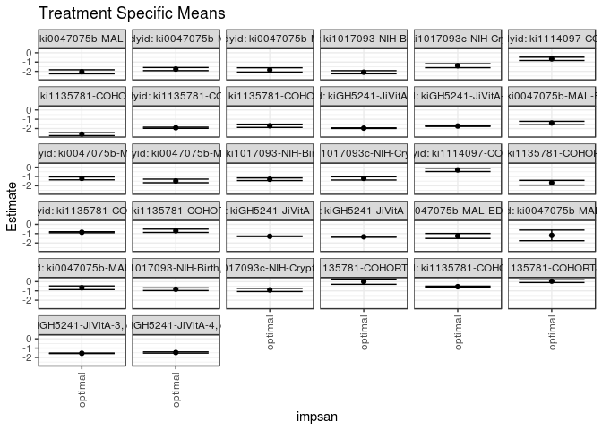

## Results Table

### Parameter: TSM

| agecat | studyid | country | intervention_level | baseline_level | estimate | ci_lower | ci_upper |
| --- | --- | --- | --- | --- | --- | --- | --- |
| Birth | ki0047075b-MAL-ED | BANGLADESH | optimal | observed | -1.2501648 | -1.5164398 | -0.9838899 |
| Birth | ki0047075b-MAL-ED | INDIA | optimal | observed | -1.1846661 | -1.7567867 | -0.6125454 |
| Birth | ki0047075b-MAL-ED | PERU | optimal | observed | -0.6680425 | -0.8637262 | -0.4723589 |
| Birth | ki1017093-NIH-Birth | BANGLADESH | optimal | observed | -0.8245431 | -0.9703913 | -0.6786950 |
| Birth | ki1017093c-NIH-Crypto | BANGLADESH | optimal | observed | -0.8965605 | -1.0694529 | -0.7236680 |
| Birth | ki1135781-COHORTS | GUATEMALA | optimal | observed | -0.0017878 | -0.2929068 | 0.2893312 |
| Birth | ki1135781-COHORTS | INDIA | optimal | observed | -0.5465595 | -0.6025502 | -0.4905688 |
| Birth | ki1135781-COHORTS | PHILIPPINES | optimal | observed | 0.0477698 | -0.1005993 | 0.1961389 |
| Birth | kiGH5241-JiVitA-3 | BANGLADESH | optimal | observed | -1.5592028 | -1.5815241 | -1.5368815 |
| Birth | kiGH5241-JiVitA-4 | BANGLADESH | optimal | observed | -1.4726214 | -1.5397147 | -1.4055280 |
| 6 months | ki0047075b-MAL-ED | BANGLADESH | optimal | observed | -1.4050264 | -1.5867085 | -1.2233442 |
| 6 months | ki0047075b-MAL-ED | INDIA | optimal | observed | -1.2051072 | -1.3642876 | -1.0459268 |
| 6 months | ki0047075b-MAL-ED | PERU | optimal | observed | -1.4821195 | -1.6765325 | -1.2877066 |
| 6 months | ki1017093-NIH-Birth | BANGLADESH | optimal | observed | -1.2983218 | -1.4404589 | -1.1561847 |
| 6 months | ki1017093c-NIH-Crypto | BANGLADESH | optimal | observed | -1.2093788 | -1.3840813 | -1.0346762 |
| 6 months | ki1114097-CONTENT | PERU | optimal | observed | -0.2920423 | -0.4719678 | -0.1121167 |
| 6 months | ki1135781-COHORTS | GUATEMALA | optimal | observed | -1.6751324 | -1.9304537 | -1.4198111 |
| 6 months | ki1135781-COHORTS | INDIA | optimal | observed | -0.8510832 | -0.9051649 | -0.7970015 |
| 6 months | ki1135781-COHORTS | PHILIPPINES | optimal | observed | -0.6906667 | -0.8692855 | -0.5120479 |
| 6 months | kiGH5241-JiVitA-3 | BANGLADESH | optimal | observed | -1.2863127 | -1.3149133 | -1.2577120 |
| 6 months | kiGH5241-JiVitA-4 | BANGLADESH | optimal | observed | -1.3427077 | -1.3909353 | -1.2944801 |
| 24 months | ki0047075b-MAL-ED | BANGLADESH | optimal | observed | -2.0509494 | -2.2653150 | -1.8365837 |
| 24 months | ki0047075b-MAL-ED | INDIA | optimal | observed | -1.7576867 | -1.9257844 | -1.5895889 |
| 24 months | ki0047075b-MAL-ED | PERU | optimal | observed | -1.8457222 | -2.0762973 | -1.6151472 |
| 24 months | ki1017093-NIH-Birth | BANGLADESH | optimal | observed | -2.0949886 | -2.2614710 | -1.9285062 |
| 24 months | ki1017093c-NIH-Crypto | BANGLADESH | optimal | observed | -1.3933875 | -1.6059731 | -1.1808019 |
| 24 months | ki1114097-CONTENT | PERU | optimal | observed | -0.6527363 | -0.8320634 | -0.4734091 |
| 24 months | ki1135781-COHORTS | GUATEMALA | optimal | observed | -2.6085854 | -2.7656397 | -2.4515310 |
| 24 months | ki1135781-COHORTS | INDIA | optimal | observed | -1.9191853 | -1.9825226 | -1.8558479 |
| 24 months | ki1135781-COHORTS | PHILIPPINES | optimal | observed | -1.7077418 | -1.8817481 | -1.5337354 |
| 24 months | kiGH5241-JiVitA-3 | BANGLADESH | optimal | observed | -1.9599277 | -1.9917252 | -1.9281301 |
| 24 months | kiGH5241-JiVitA-4 | BANGLADESH | optimal | observed | -1.7307019 | -1.7728648 | -1.6885389 |

### Parameter: E(Y)

| agecat | studyid | country | intervention_level | baseline_level | estimate | ci_lower | ci_upper |
| --- | --- | --- | --- | --- | --- | --- | --- |
| Birth | ki0047075b-MAL-ED | BANGLADESH | observed | observed | -1.0530516 | -1.1896058 | -0.9164975 |
| Birth | ki0047075b-MAL-ED | INDIA | observed | observed | -1.1375000 | -1.4325178 | -0.8424822 |
| Birth | ki0047075b-MAL-ED | PERU | observed | observed | -0.9131731 | -1.0331160 | -0.7932301 |
| Birth | ki1017093-NIH-Birth | BANGLADESH | observed | observed | -0.9310197 | -1.0197391 | -0.8423003 |
| Birth | ki1017093c-NIH-Crypto | BANGLADESH | observed | observed | -0.9131068 | -0.9851939 | -0.8410197 |
| Birth | ki1135781-COHORTS | GUATEMALA | observed | observed | -0.0275356 | -0.1359303 | 0.0808590 |
| Birth | ki1135781-COHORTS | INDIA | observed | observed | -0.6777115 | -0.7106054 | -0.6448175 |
| Birth | ki1135781-COHORTS | PHILIPPINES | observed | observed | -0.3137364 | -0.3764483 | -0.2510244 |
| Birth | kiGH5241-JiVitA-3 | BANGLADESH | observed | observed | -1.5898288 | -1.6090823 | -1.5705753 |
| Birth | kiGH5241-JiVitA-4 | BANGLADESH | observed | observed | -1.5236135 | -1.5727559 | -1.4744711 |
| 6 months | ki0047075b-MAL-ED | BANGLADESH | observed | observed | -1.2026806 | -1.3203025 | -1.0850586 |
| 6 months | ki0047075b-MAL-ED | INDIA | observed | observed | -1.2087268 | -1.3282418 | -1.0892117 |
| 6 months | ki0047075b-MAL-ED | PERU | observed | observed | -1.3196229 | -1.4293681 | -1.2098778 |
| 6 months | ki1017093-NIH-Birth | BANGLADESH | observed | observed | -1.4073821 | -1.4960598 | -1.3187043 |
| 6 months | ki1017093c-NIH-Crypto | BANGLADESH | observed | observed | -1.2031037 | -1.2749632 | -1.1312442 |
| 6 months | ki1114097-CONTENT | PERU | observed | observed | -0.3139217 | -0.4868486 | -0.1409948 |
| 6 months | ki1135781-COHORTS | GUATEMALA | observed | observed | -1.8789210 | -1.9609921 | -1.7968498 |
| 6 months | ki1135781-COHORTS | INDIA | observed | observed | -1.0414424 | -1.0741113 | -1.0087734 |
| 6 months | ki1135781-COHORTS | PHILIPPINES | observed | observed | -1.1942936 | -1.2608624 | -1.1277248 |
| 6 months | kiGH5241-JiVitA-3 | BANGLADESH | observed | observed | -1.3134804 | -1.3366079 | -1.2903528 |
| 6 months | kiGH5241-JiVitA-4 | BANGLADESH | observed | observed | -1.3440477 | -1.3813060 | -1.3067894 |
| 24 months | ki0047075b-MAL-ED | BANGLADESH | observed | observed | -1.9783962 | -2.1050210 | -1.8517715 |
| 24 months | ki0047075b-MAL-ED | INDIA | observed | observed | -1.8779556 | -2.0033207 | -1.7525904 |
| 24 months | ki0047075b-MAL-ED | PERU | observed | observed | -1.7535204 | -1.8760973 | -1.6309435 |
| 24 months | ki1017093-NIH-Birth | BANGLADESH | observed | observed | -2.2190579 | -2.3217459 | -2.1163699 |
| 24 months | ki1017093c-NIH-Crypto | BANGLADESH | observed | observed | -1.4417097 | -1.5263855 | -1.3570340 |
| 24 months | ki1114097-CONTENT | PERU | observed | observed | -0.6962195 | -0.8674103 | -0.5250287 |
| 24 months | ki1135781-COHORTS | GUATEMALA | observed | observed | -3.0050840 | -3.0758338 | -2.9343342 |
| 24 months | ki1135781-COHORTS | INDIA | observed | observed | -2.2126633 | -2.2518337 | -2.1734929 |
| 24 months | ki1135781-COHORTS | PHILIPPINES | observed | observed | -2.5937576 | -2.6629996 | -2.5245156 |
| 24 months | kiGH5241-JiVitA-3 | BANGLADESH | observed | observed | -2.0136975 | -2.0413718 | -1.9860232 |
| 24 months | kiGH5241-JiVitA-4 | BANGLADESH | observed | observed | -1.7803708 | -1.8158650 | -1.7448765 |

### Parameter: PAR

| agecat | studyid | country | intervention_level | baseline_level | estimate | ci_lower | ci_upper |
| --- | --- | --- | --- | --- | --- | --- | --- |
| Birth | ki0047075b-MAL-ED | BANGLADESH | optimal | observed | 0.1971132 | -0.0316422 | 0.4258686 |
| Birth | ki0047075b-MAL-ED | INDIA | optimal | observed | 0.0471661 | -0.3686505 | 0.4629827 |
| Birth | ki0047075b-MAL-ED | PERU | optimal | observed | -0.2451305 | -0.4193393 | -0.0709218 |
| Birth | ki1017093-NIH-Birth | BANGLADESH | optimal | observed | -0.1064766 | -0.2178311 | 0.0048778 |
| Birth | ki1017093c-NIH-Crypto | BANGLADESH | optimal | observed | -0.0165463 | -0.1683823 | 0.1352896 |
| Birth | ki1135781-COHORTS | GUATEMALA | optimal | observed | -0.0257478 | -0.2911667 | 0.2396711 |
| Birth | ki1135781-COHORTS | INDIA | optimal | observed | -0.1311519 | -0.1768878 | -0.0854161 |
| Birth | ki1135781-COHORTS | PHILIPPINES | optimal | observed | -0.3615061 | -0.5027642 | -0.2202481 |
| Birth | kiGH5241-JiVitA-3 | BANGLADESH | optimal | observed | -0.0306260 | -0.0423403 | -0.0189117 |
| Birth | kiGH5241-JiVitA-4 | BANGLADESH | optimal | observed | -0.0509921 | -0.0985820 | -0.0034023 |
| 6 months | ki0047075b-MAL-ED | BANGLADESH | optimal | observed | 0.2023458 | 0.0551528 | 0.3495388 |
| 6 months | ki0047075b-MAL-ED | INDIA | optimal | observed | -0.0036196 | -0.1242775 | 0.1170383 |
| 6 months | ki0047075b-MAL-ED | PERU | optimal | observed | 0.1624966 | 0.0119288 | 0.3130644 |
| 6 months | ki1017093-NIH-Birth | BANGLADESH | optimal | observed | -0.1090603 | -0.2206685 | 0.0025479 |
| 6 months | ki1017093c-NIH-Crypto | BANGLADESH | optimal | observed | 0.0062751 | -0.1554601 | 0.1680103 |
| 6 months | ki1114097-CONTENT | PERU | optimal | observed | -0.0218795 | -0.0647786 | 0.0210197 |
| 6 months | ki1135781-COHORTS | GUATEMALA | optimal | observed | -0.2037885 | -0.4479846 | 0.0404075 |
| 6 months | ki1135781-COHORTS | INDIA | optimal | observed | -0.1903592 | -0.2350681 | -0.1456502 |
| 6 months | ki1135781-COHORTS | PHILIPPINES | optimal | observed | -0.5036269 | -0.6733549 | -0.3338990 |
| 6 months | kiGH5241-JiVitA-3 | BANGLADESH | optimal | observed | -0.0271677 | -0.0426545 | -0.0116809 |
| 6 months | kiGH5241-JiVitA-4 | BANGLADESH | optimal | observed | -0.0013400 | -0.0294443 | 0.0267643 |
| 24 months | ki0047075b-MAL-ED | BANGLADESH | optimal | observed | 0.0725531 | -0.1134169 | 0.2585232 |
| 24 months | ki0047075b-MAL-ED | INDIA | optimal | observed | -0.1202689 | -0.2513341 | 0.0107963 |
| 24 months | ki0047075b-MAL-ED | PERU | optimal | observed | 0.0922018 | -0.1079683 | 0.2923719 |
| 24 months | ki1017093-NIH-Birth | BANGLADESH | optimal | observed | -0.1240693 | -0.2462538 | -0.0018848 |
| 24 months | ki1017093c-NIH-Crypto | BANGLADESH | optimal | observed | -0.0483222 | -0.2383926 | 0.1417481 |
| 24 months | ki1114097-CONTENT | PERU | optimal | observed | -0.0434832 | -0.0897935 | 0.0028270 |
| 24 months | ki1135781-COHORTS | GUATEMALA | optimal | observed | -0.3964986 | -0.5517134 | -0.2412839 |
| 24 months | ki1135781-COHORTS | INDIA | optimal | observed | -0.2934780 | -0.3459454 | -0.2410106 |
| 24 months | ki1135781-COHORTS | PHILIPPINES | optimal | observed | -0.8860158 | -1.0549467 | -0.7170849 |
| 24 months | kiGH5241-JiVitA-3 | BANGLADESH | optimal | observed | -0.0537699 | -0.0694692 | -0.0380705 |
| 24 months | kiGH5241-JiVitA-4 | BANGLADESH | optimal | observed | -0.0496689 | -0.0691576 | -0.0301802 |